[figure not shown]

### Secured Overnight Financing Rate Data

The Secured Overnight Financing Rate (SOFR) is a broad measure of the cost of borrowing cash overnight collateralized by Treasury securities. The SOFR includes all trades in the Broad General Collateral Rate plus bilateral Treasury repurchase agreement (repo) transactions cleared through the Delivery-versus-Payment (DVP) service offered by the Fixed Income Clearing Corporation (FICC), which is filtered to remove a portion of transactions considered “specials”.

The SOFR is calculated as a volume-weighted median of transaction-level tri-party repo data collected from the Bank of New York Mellon as well as GCF Repo transaction data and data on bilateral Treasury repo transactions cleared through FICC’s DVP service, which are obtained from DTCC Solutions LLC, an affiliate of the Depository Trust & Clearing Corporation. Each business day, the New York Fed publishes the SOFR on the New York Fed website at approximately 8:00 a.m. ET.

For more information on the production of the SOFR, please see [Additional Information about the Treasury Repo Reference Rates](https://www.newyorkfed.org/markets/treasury-repo-reference-rates-information).

To access historical data, please see: [Repo Rates Data Historical Search](https://apps.newyorkfed.org/markets/autorates/rates-search-page?rateType=R3)

In 2014, the Federal Reserve created the Alternative Reference Rates Committee (ARRC) for the purpose of determining potential alternative rates for Libor, along with ideas for implementing the U.S. financial markets’ transition to a chosen replacement rate.

SOFR addresses the vulnerabilities of Libor in two ways. It is based on actual lending rates between banks, which helps reduce the risk of manipulation. Meanwhile, unlike SOFR, Libor is not compliant with the International Organization of Securities Commissions (IOSCO), the international body that brings together the world’s securities regulators and is recognized as the global standard setter for the securities sector. IOSCO develops, implements, and promotes adherence to internationally recognized standards for securities regulation.

Accordingly, SOFR is a good representation of general funding conditions in the overnight Treasury repo market. As such, it will reflect an economic cost of lending and borrowing relevant to the wide array of market participants active in the market, including not only broker-dealers, but also money market funds, asset managers, insurance companies, securities lenders, and pension funds.

The ARRC believes that SOFR is the most appropriate reference rate for widespread and long-term adoption as market participants seek to transition from Libor. The reasons include the following:

1. It is IOSCO compliant and fully transaction-based.
2. It encompasses a robust underlying repo market with more than $700 billion in daily transactions.
3. It is an overnight, nearly risk-free reference rate that correlates closely with other money market rates.
4. It covers multiple repo-market segments, allowing for future market evolution.

The introduction of SOFR as a published rate highlights how important it is for U.S. banks to plan their transition away from Libor sooner rather than later. While the regulators clearly do not expect banks to stop using Libor and begin using SOFR immediately, banks would be well advised to take stock of their current portfolio in advance of 2021. That way they will be able to discover Libor-related issues within their loan documentation and potentially address those issues with time to spare-instead of addressing them in 2021 when Libor (and thus the reference rate for their loans) may no longer be in existence.

U.S. banks should also begin considering a plan for implementing SOFR or an alternative interest rate in their loan documents going forward. Otherwise, banks risk compounding problems in their existing loan portfolio by adding even more Libor loans that may require attention if and when Libor is no longer published.

The paced transition from Libor to SOFR is to allow for the new issuance of SOFR-related products and for the market to organically adopt the new rate. The CME Group derivatives marketplace announced in October that five market participants cleared trades worth more than $200 million in notional value of over-the-counter SOFR interest rate swaps since launching the service.

Fannie Mae, the World Bank, and Credit Suisse are pioneers of the market’s first SOFR-based securities. Fannie Mae issued a $6 billion SOFR debt transaction, the World Bank raised its first SOFR two-year USD-denominated benchmark bond in the amount of $1 billion from investors in the Americas and Europe, and Credit Suisse sold a $100 million, six-month certificate of deposit. These new issuances of SOFR products should foster liquidity in the derivatives hedging market.

[Attribute Information](https://apps.newyorkfed.org/markets/autorates/SOFR)

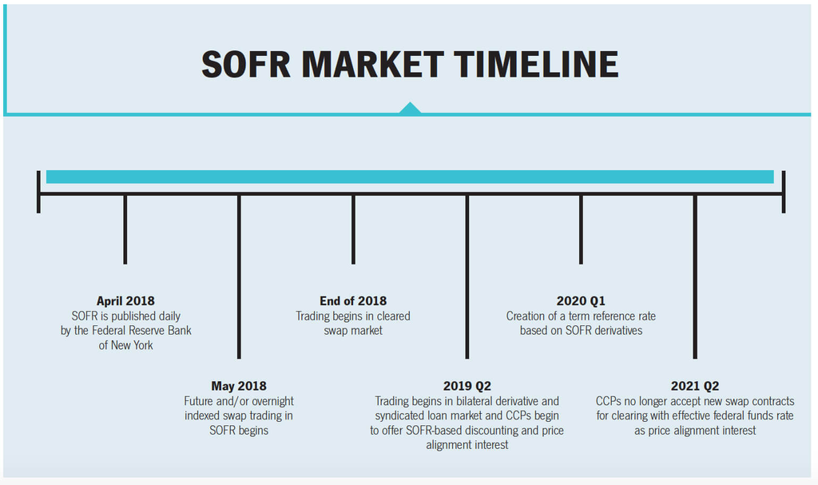